# 04-home-field-advantage

Yuting Mei

October 11, 2021

```r
# library(data.table)
library("dplyr")
library(tidyverse)
library(ggplot2)
```

```r
library(readr)
apo <- read_csv("all-possible-world-series-outcomes.csv")
```

```r
library(data.table)
```

# 1 introduction

The home field advantage is the edge which a team may have when playing a game at its home stadium. For example, it is the edge the Braves may have over the Yankees when the head-to-head match-up is in Atlanta. It is the advantage the Yankees may have when the head-to-head match-up is in New York.

The World Series is a first-to-4-wins match-up between the champions of the American and National Leagues of Major League Baseball. In this assignment, you are going to use simulation and analytic methods to compare the probability of winning the World Series with and without home field advantage.

## 1.1 Set up

- Suppose that the Braves and the Yankees are teams competing in the World Series.
- The table below has the two possible schedules for each game of the series. (NYC = New York City, ATL = Atlanta)

| Overall advantage | Game1 | Game2 | Game3 | Game4 | Game5 | Game6 | Game7 |
| --- | --- | --- | --- | --- | --- | --- | --- |
| Braves | ATL | ATL | NYC | NYC | NYC | ATL | ATL |
| Yankees | NYC | NYC | ATL | ATL | ATL | NYC | NYC |

- Let $P_B$ be the probability that the Braves win a single head-to-head match-up with the Yankees, under the assumption that home field advantage doesn’t exist. Let $P_B^H$ denote the probability that the Braves win a single head-to-head match-up with the Yankees as the home team (H for home). Let $P_B^A$ denote the probability that the Braves win a single head-to-head match-up with the away team (A for away).

| Game location | No Advantage | Advantage |
| --- | --- | --- |
| ATL | $P_B$ | $P_B^H = P_B*1.1$ |
| NYC | $P_B$ | $P_B^A = 1-(1-P_B)*1.1$ |

## 1.2 Assumption

- Braves and Yankees will not affect each other during the game.
- There is no external force that affects or interrupts the game between the two teams.
- The players of the two teams all played steadily during the game.
- The probability of each team in each game obeys independent and identical distribution
- The game must be over seven rounds before it is over

# 2 Method

If you are interested in how Braves win the world series games, and how to calculate the probability each time without advantage, you can click the link below: https://github.com/vanderbilt-data-science/probability-and-inference-portfolio-mei-yuting/tree/main/03-discrete-probability-calculations

When we condider the advantage, we need to find each probability of winning accoding to the game location. Since each game is an indepedent event with each other, so we can multiple them together to get the final probability of compound event.

## 2.1 Terminology

**Simulation**  
Simulation is a way to model random events, such that simulated outcomes closely match real-world outcomes. By observing simulated outcomes, researchers gain insight on the real world.

if you are interested in how simulation and analytic method works? why we need them? What is the pros and cons between the two mehods? You can click the link below: https://github.com/vanderbilt-data-science/probability-and-inference-portfolio-mei-yuting/tree/main/ec1-birthday-problem

**Random Sampling**  
In statistics, a finite subset of individuals from a population is called a sample. In random sampling, the samples are drawn at random from the population, which implies that each unit of population has an equal chance of being included in the sample.

**Negative Binomial Distribution**  
In probability theory and statistics, the negative binomial distribution is a discrete probability distribution that models the number of successes in a sequence of independent and identically distributed Bernoulli trials before a specified (non-random) number of failures (denoted r) occurs. For example, we can define rolling a 6 on a die as a failure, and rolling any other number as a success, and ask how many successful rolls will occur before we see the third failure (r = 3). In such a case, the probability distribution of the number of non-6s that appear will be a negative binomial distribution.

The probability mass function of the negative binomial distribution is: $f(k;r,p)\equiv\Pr(X\equiv k)=\binom{k+r-1}{r-1}(1-p)^kp^r$ where r is the number of successes, k is the number of failures, and p is the probability of success.

**Independent events**  
An independent event is an event that has no connection to another event’s chances of happening (or not happening). In other words, the event has no effect on the probability of another event occurring.

**Law of large numbers**  
In probability theory, the law of large numbers (LLN) is a theorem that describes the result of performing the same experiment a large number of times. According to the law, the average of the results obtained from a large number of trials should be close to the expected value and will tend to become closer to the expected value as more trials are performed.

**Absolute Error**  
Absolute Error is the amount of error in your measurements. It is the difference between the measured value and “true” value.

The absolute error of the experiment is: absolute error = $|p - \widehat{p} |$, where $\widehat{p}$ is approximate error.

**Relative Error**  
Relative error is a measure of the uncertainty of measurement compared to the size of the measurement. It’s used to put error into perspective.

The relative error of the experiment is: relative error = $\frac{|p - \widehat{p} |}{p}$, where $\widehat{p}$ is approximate error.

# 3 Result

## 3.1 Question 1

Compute analytically the probability that the Braves win the world series when the sequence of game locations is {NYC, NYC, ATL, ATL, ATL, NYC, NYC}. Calculate the probability with and without home field advantage when $P_B=0.55$. What is the difference in probabilities?

```r
# analytic

# with advantage
# Get all possible outcomes
# apo <- fread("all-possible-world-series-outcomes.csv")

# Home field indicator
hfi <- c(0,0,1,1,1,0,0) #{NYC, NYC, ATL, ATL, ATL, NYC, NYC}

# P_B
pb <- 0.55
advantage_multiplier <- 1.1 # Set = 1 for no advantage
pbh <- 0.55*advantage_multiplier
pba <- 1 - (1 - 0.55)*advantage_multiplier

apo = data.table(apo)

# Calculate the probability of each possible outcome
apo[, p := NA_real_] # Initialize new column in apo to store prob
for(i in 1:nrow(apo)){
  prob_game <- rep(1, 7)
  for(j in 1:7){
    p_win <- ifelse(hfi[j], pbh, pba)
    prob_game[j] <- case_when(
        apo[i,j,with=FALSE] == "W" ~ p_win
      , apo[i,j,with=FALSE] == "L" ~ 1 - p_win
      , TRUE ~ 1
    )
  }
  apo[i, p := prod(prob_game)] # Data.table syntax
}

# Sanity check: does sum(p) == 1?
# apo[, sum(p)] # This is data.table notation

# Probability of overall World Series outcomes
# apo[, sum(p), overall_outcome]
prob_with = apo[, sum(p), overall_outcome][1,2]
# prob_with = apo[, sum(p), overall_outcome]
prob_with
```

```
##          V1
## 1: 0.604221
```

```r
# without advantage
prob_without = pnbinom(3, 4, 0.55)
prob_without
```

```
## [1] 0.6082878
```

The step to calculate the probability of the final outcome by using analytic method is to divide the target event into three steps. In the first step, we need to list all possible game results. The second step is to multiply the probability of Braves’s home win in seven games to obtain all the possibilities(because all events are independent and identically distributed, so each events that Braves win and lose the competition are independent events). The corresponding probability that the result will appear, the last step is to add up the probability of the event that Braves wins and divide the result by the total probability (which should equals to 1).The probability of Braves win the world series with advantage by using analytic method is 0.604221. And the number shows the probability of Braves win the world series without advantage by usinf analytic method is 0.60828.

## 3.2 Question 2

Calculate the same probabilities as the previous question by simulation.

```r
# simulation
# with advantage

# generate_game is designed to do sampling simulation of the results of the games, the expected outcome is a data frame with the first column: the index of games, the second column: the possible outcome of Braves at each round(0 represents lose and 1 represents win)
generate_game = function(game_number){
  game_outcome = c()
# Need to complete seven rounds every time
for(i in 1:length(hfi)){
  # In order to ensure that the two teams can complete seven games, it is necessary to exclude all situations where the game ends before the seventh game: 1. Win in advance: win more than three times before the seventh game; 2. Lose in advance: in the seventh game Losing more than three times before a round (getting zero points in the first four rounds, only getting one point in the first five rounds, and only two points in the first six rounds), which is equivalent to winning i-4 or less in the first i round (when i>4)
  if(sum(game_outcome, na.rm = TRUE) < 4){
    if(i < 4 | (sum(game_outcome, na.rm = TRUE) >= (i - 4))){
      game_outcome[i] = case_when(
    hfi[i] == 0 ~ sample(0:1, 1, replace = TRUE, prob = c(1 - pba, pba)),
    hfi[i] == 1 ~ sample(0:1, 1, replace = TRUE, prob = c(1 - pbh, pbh))
    )
    }
    else{
      game_outcome[i] = NA
    }
  }
  else{
    game_outcome[i] = NA
  }
}
  if(sum(game_outcome, na.rm = TRUE) <= 2){
    game_outcome[length(hfi)] = NA
  }
data.frame(game_index = 1:game_number, game_outcome)
}


check_final = function(df){
df %>%
  summarise(final_outcome = ifelse(sum(df[, 2], na.rm = TRUE) == 4, 1, 0))
}
```

```r
prob_with_hat = replicate(50000, generate_game(7) %>% check_final()) %>% as.numeric() %>% mean(na.rm = TRUE)
prob_with_hat
```

```
## [1] 0.61146
```

```r
# simulation
# without advantage
generate_game2 = function(game_number){
  game_outcome = c()
for(i in 1:game_number){
  if(sum(game_outcome, na.rm = TRUE) < 4){
    if(i < 4 | (sum(game_outcome, na.rm = TRUE) >= (i - 4))){
      game_outcome[i] = sample(0:1, 1, replace = TRUE, prob = c(1 - pb, pb))
    }
    else{
      game_outcome[i] = NA
    }
  }
  else{
    game_outcome[i] = NA
  }
}
  if(sum(game_outcome, na.rm = TRUE) <= 2){
    game_outcome[length(hfi)] = NA
  }
data.frame(game_index = 1:game_number, game_outcome)
}

check_final2 = function(df){
df %>%
  summarise(final_outcome = ifelse(sum(df[, 2], na.rm = TRUE) == 4, 1, 0))
}
```

```r
prob_without_hat = replicate(50000, generate_game2(7) %>% check_final2()) %>% as.numeric() %>% mean(na.rm = TRUE)
prob_without_hat
```

```
## [1] 0.6109
```

## 3.3 Question 3

What is the absolute and relative error for your simulation in the previous question?

```r
# calculate absolute error and relative error with advantage
(absolute_error_with = abs(prob_with - prob_with_hat))
```

```
##             V1
## 1: 0.007239028
```

```r
(relative_error_with = abs(prob_with - prob_with_hat) / prob_with)
```

```
##            V1
## 1: 0.01198076
```

```r
# calculate absolute error and relative error without advantage
(absolute_error_without = abs(prob_without - prob_without_hat))
```

```
## [1] 0.002612203
```

```r
(relative_error_without = abs(prob_without - prob_without_hat) / prob_without)
```

```
## [1] 0.004294354
```

```r
# different probabilities depend on pb

# analytic with advantage
prob_with_seq = c()
prob_b = c()
apo[, p := NA_real_] # Initialize new column in apo to store prob
for(k in seq(1, 41)){
  prob_b[k] = 0.5 + 0.01 * (k - 1)
  pbh <- prob_b[k]*advantage_multiplier
  pba <- 1 - (1 - prob_b[k])*advantage_multiplier
  # Calculate the probability of each possible outcome
for(i in 1:nrow(apo)){
  prob_game <- rep(1, 7)
  for(j in 1:7){
    p_win <- ifelse(hfi[j], pbh, pba)
    prob_game[j] <- case_when(
        apo[i,j,with=FALSE] == "W" ~ p_win
      , apo[i,j,with=FALSE] == "L" ~ 1 - p_win
      , TRUE ~ 1
    )
  }
  apo[i, p := prod(prob_game)] # Data.table syntax
  }
prob_with_seq[k] = apo[, sum(p), overall_outcome][1,2] %>% as.numeric()
}
```

```r
# analytics without advantage
prob_without_seq_2 = c()
for(i in 1:41){
  prob_b[i] = 0.5 + 0.01 * (i - 1)
  prob_without_seq_2[i] = pnbinom(3, 4, prob_b[i])
}
```

## 3.4 Question 4

Does the difference in probabilities (with vs without home field advantage) depend on PB? (Generate a plot to answer this question.)

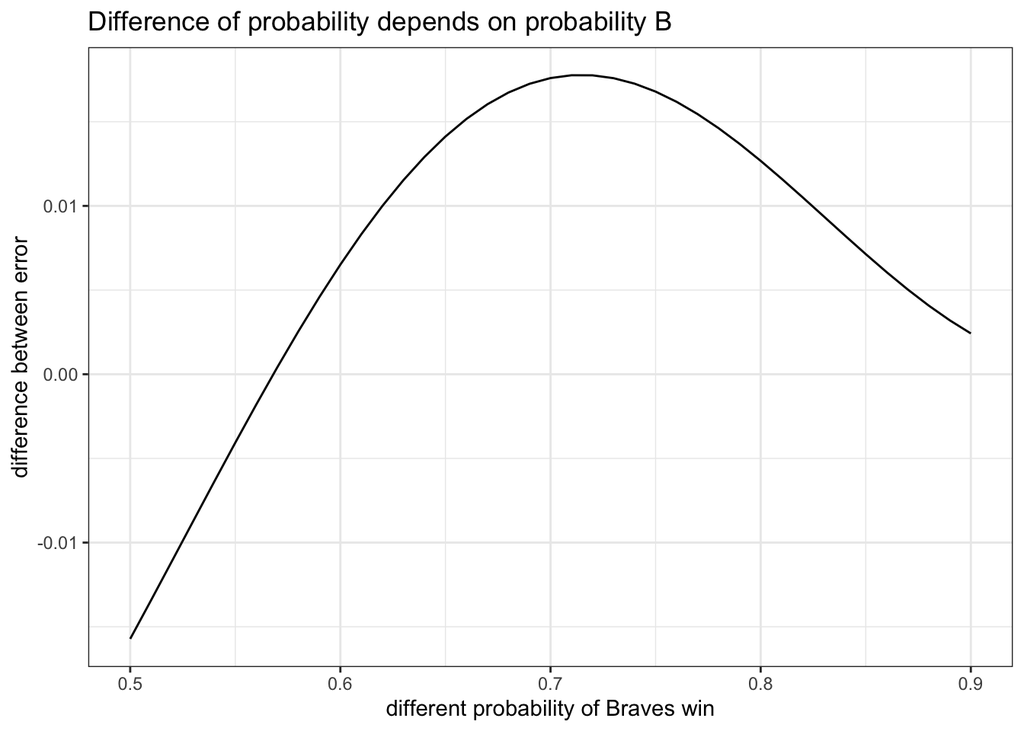

```r
prob_b = c()
for(i in 1:41){
  prob_b[i] = 0.5 + 0.01 * (i - 1)
}
sum = data.frame(prob_b, prob_with_seq, prob_without_seq_2)
sum$difference = sum$prob_with_seq - sum$prob_without_seq_2

ggplot(sum, aes(x = prob_b)) +
  geom_line(aes(y = difference)) +
  # geom_line(aes(y = prob_with_seq)) +
  # geom_line(aes(y = prob_without_seq_2)) +
  labs(x = "different probability of Braves win", y = "difference between error",
       title = "Difference of probability depends on probability B") +
  theme_bw()
```

The above figure shows how the difference of probability with and without advantage changes when the $P_B$ changes. The x axis represents the $P_B$ changes from 0.5 to 0.9, and the y axis represents the corresponding difference of probabilities with and without advantage.

```r
# different probabilities depend on advantage

# analytic with different advantage(when advantage = 1, there is no advantage)
prob_with_seq_a = c()
advantage = c()
apo[, p := NA_real_] # Initialize new column in apo to store prob
for(k in seq(1, 9)){
  prob_b = 0.55
  advantage[k] = 1 + 0.1 *(k -1)
  pbh <- prob_b*advantage[k]
  pba <- 1 - (1 - prob_b)*advantage[k]
  # Calculate the probability of each possible outcome
for(i in 1:nrow(apo)){
  prob_game <- rep(1, 7)
  for(j in 1:7){
    p_win <- ifelse(hfi[j], pbh, pba)
    prob_game[j] <- case_when(
        apo[i,j,with=FALSE] == "W" ~ p_win
      , apo[i,j,with=FALSE] == "L" ~ 1 - p_win
      , TRUE ~ 1
    )
  }
  apo[i, p := prod(prob_game)] # Data.table syntax
  }
prob_with_seq_a[k] = apo[, sum(p), overall_outcome][1,2] %>% as.numeric()
}
```

## 3.5 Question 5

Does the difference in probabilities (with vs without home field advantage) depend on the advantage factor? (The advantage factor in PBH and PBA is the 1.1 multiplier that results in a 10% increase for the home team. Generate a plot to answer this question.)

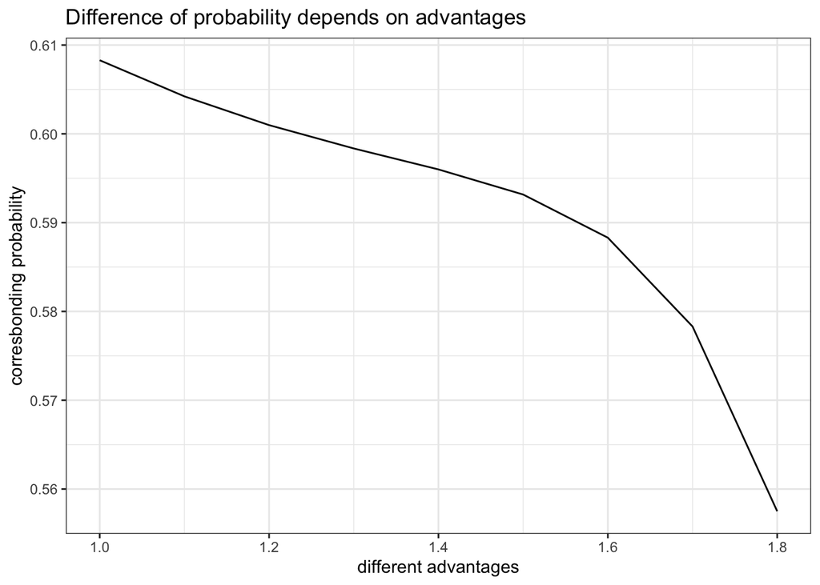

```r
sum_a = data.frame(advantage, prob_with_seq_a)

ggplot(sum_a, aes(x = advantage, y = prob_with_seq_a)) +
  geom_line() +
  labs(x = "different advantages", y = "corresbonding probability",
       title = "Difference of probability depends on advantages") +
  theme_bw()
```

The above figure shows how the difference in probabilities (with vs without home field advantage) depend on the advantage factor. The x axis represents the different advantages(from 1 to 1.8), and the y axis represents the probabilities of winning with different advantages, $P_B$ in this figure equals to 0.55.

# 4 Conclusion